# Wrangle and Analyze Data

- Introduction
- Gathering Data
- Assessing Data
- Cleaning Data
- Data Analysis

## Introduction

> In this project, I'll gather, assess, and clean data then act on it through analysis, visualization and/or modeling.

Unpolplar dog name

## Gathering Data

#### Data are in 3 three forms:

> - CSV (Manual download from The WeRateDogs Twitter archive) [archived_data]
> - TSV ( Download the file programicatly ) [prediction_data]
> - JSON (Using tweepy API) [tweet_data]

```python
!pip install tweepy
```

```python
#import dependencies
import numpy as np
import pandas as pd
import matplotlib.pyplot as plt
import tweepy
from tweepy import OAuthHandler
from timeit import default_timer as timer
import json
import requests
import os
import IPython
%matplotlib inline
```

## Load each data format into df

### 1. archived data

```python
# load csv file int df
archived_data = pd.read_csv('twitter-archive-enhanced.csv')
```

### 2. prediction_data

```python
# Make directory if it doesn't already exist
folder_name = 'prediction_data'
if not os.path.exists(folder_name):
    os.makedirs(folder_name)

url = 'https://d17h27t6h515a5.cloudfront.net/topher/2017/August/599fd2ad_image-predictions/image-predictions.tsv'
response = requests.get(url)
```

```python
with open(os.path.join(folder_name, url.split('/')[-1]), mode='wb') as file:
    file.write(response.content)

prediction_data = pd.read_csv('{}/image-predictions.tsv'.format(folder_name), sep = '\t')
```

### 3. tweet_data

```python
consumer_key = ''
consumer_secret = ''
access_token = ''
access_secret = ''

auth = OAuthHandler(consumer_key, consumer_secret)
auth.set_access_token(access_token, access_secret)

api = tweepy.API(auth, wait_on_rate_limit=True ,wait_on_rate_limit_notify=True)


tweet_ids = archived_data.tweet_id.values
len(tweet_ids)

# Query Twitter's API for JSON data for each tweet ID in the Twitter archive
count = 0
fails_dict = {}

# Save each tweet's returned JSON as a new line in a .txt file
if not os.path.isfile('tweet_json.txt'):
    with open('tweet_json.txt', 'w') as outfile:
        # This loop will likely take 20-30 minutes to run because of Twitter's rate limit
        for tweet_id in tweet_ids:
            count += 1
            print(str(count) + ": " + str(tweet_id))
            try:
                tweet = api.get_status(tweet_id, tweet_mode='extended')
                print("Success")
                json.dump(tweet._json, outfile)
                outfile.write('\n')
            except tweepy.TweepError as e:
                print("Fail")
                fails_dict[tweet_id] = e
                pass
print(fails_dict)
#tweet_json.txt is the generated file.
```

```
{}
```

```python
tweets_list = []
with open('tweet_json.txt' , 'r') as file:
    for line in file.readlines():
        tweets_json = json.loads(line)
        fav_count = tweets_json['favorite_count']
        retweet_count = tweets_json['retweet_count']
        tweet_id = tweets_json['id_str']
        tweets_list.append({'favorite_count':fav_count,
                            'retweet_count':retweet_count,
                            'tweet_id': tweet_id})
```

```python
# Create tweet_data DataFrame
tweet_data = pd.DataFrame(tweets_list,columns = ['tweet_id','favorite_count','retweet_count'])
```

## Assessing Data

#### 'archived_data'

```python
#check is ther null rows
archived_data.info()
```

```
<class 'pandas.core.frame.DataFrame'>
RangeIndex: 2356 entries, 0 to 2355
Data columns (total 17 columns):
tweet_id                      2356 non-null int64
in_reply_to_status_id         78 non-null float64
in_reply_to_user_id           78 non-null float64
timestamp                     2356 non-null object
source                        2356 non-null object
text                          2356 non-null object
retweeted_status_id           181 non-null float64
retweeted_status_user_id      181 non-null float64
retweeted_status_timestamp    181 non-null object
expanded_urls                 2297 non-null object
rating_numerator              2356 non-null int64
rating_denominator            2356 non-null int64
name                          2356 non-null object
doggo                         2356 non-null object
floofer                       2356 non-null object
pupper                        2356 non-null object
puppo                         2356 non-null object
dtypes: float64(4), int64(3), object(10)
memory usage: 313.0+ KB
```

```python
archived_data.head()
```

|  | tweet_id | in_reply_to_status_id | in_reply_to_user_id | timestamp | source | text | retweeted_status_id | retweeted_status_user_id | retweeted_status_timestamp | expanded_urls | rating_numerator | rating_denominator | name | doggo | floofer | pupper | puppo |
| --- | --- | --- | --- | --- | --- | --- | --- | --- | --- | --- | --- | --- | --- | --- | --- | --- | --- |
| 0 | 892420643555336193 | NaN | NaN | 2017-08-01 16:23:56 +0000 | <a href="http://twitter.com/download/iphone" r... | This is Phineas. He's a mystical boy. Only eve... | NaN | NaN | NaN | https://twitter.com/dog_rates/status/892420643... | 13 | 10 | Phineas | None | None | None | None |
| 1 | 892177421306343426 | NaN | NaN | 2017-08-01 00:17:27 +0000 | <a href="http://twitter.com/download/iphone" r... | This is Tilly. She's just checking pup on you.... | NaN | NaN | NaN | https://twitter.com/dog_rates/status/892177421... | 13 | 10 | Tilly | None | None | None | None |
| 2 | 891815181378084864 | NaN | NaN | 2017-07-31 00:18:03 +0000 | <a href="http://twitter.com/download/iphone" r... | This is Archie. He is a rare Norwegian Pouncin... | NaN | NaN | NaN | https://twitter.com/dog_rates/status/891815181... | 12 | 10 | Archie | None | None | None | None |
| 3 | 891689557279858688 | NaN | NaN | 2017-07-30 15:58:51 +0000 | <a href="http://twitter.com/download/iphone" r... | This is Darla. She commenced a snooze mid meal... | NaN | NaN | NaN | https://twitter.com/dog_rates/status/891689557... | 13 | 10 | Darla | None | None | None | None |
| 4 | 891327558926688256 | NaN | NaN | 2017-07-29 16:00:24 +0000 | <a href="http://twitter.com/download/iphone" r... | This is Franklin. He would like you to stop ca... | NaN | NaN | NaN | https://twitter.com/dog_rates/status/891327558... | 12 | 10 | Franklin | None | None | None | None |

```python
archived_data.tail()
```

|  | tweet_id | in_reply_to_status_id | in_reply_to_user_id | timestamp | source | text | retweeted_status_id | retweeted_status_user_id | retweeted_status_timestamp | expanded_urls | rating_numerator | rating_denominator | name | doggo | floofer | pupper | puppo |
| --- | --- | --- | --- | --- | --- | --- | --- | --- | --- | --- | --- | --- | --- | --- | --- | --- | --- |
| 2351 | 666049248165822465 | NaN | NaN | 2015-11-16 00:24:50 +0000 | <a href="http://twitter.com/download/iphone" r... | Here we have a 1949 1st generation vulpix. Enj... | NaN | NaN | NaN | https://twitter.com/dog_rates/status/666049248... | 5 | 10 | None | None | None | None | None |
| 2352 | 666044226329800704 | NaN | NaN | 2015-11-16 00:04:52 +0000 | <a href="http://twitter.com/download/iphone" r... | This is a purebred Piers Morgan. Loves to Netf... | NaN | NaN | NaN | https://twitter.com/dog_rates/status/666044226... | 6 | 10 | a | None | None | None | None |
| 2353 | 666033412701032449 | NaN | NaN | 2015-11-15 23:21:54 +0000 | <a href="http://twitter.com/download/iphone" r... | Here is a very happy pup. Big fan of well-main... | NaN | NaN | NaN | https://twitter.com/dog_rates/status/666033412... | 9 | 10 | a | None | None | None | None |
| 2354 | 666029285002620928 | NaN | NaN | 2015-11-15 23:05:30 +0000 | <a href="http://twitter.com/download/iphone" r... | This is a western brown Mitsubishi terrier. Up... | NaN | NaN | NaN | https://twitter.com/dog_rates/status/666029285... | 7 | 10 | a | None | None | None | None |
| 2355 | 666020888022790149 | NaN | NaN | 2015-11-15 22:32:08 +0000 | <a href="http://twitter.com/download/iphone" r... | Here we have a Japanese Irish Setter. Lost eye... | NaN | NaN | NaN | https://twitter.com/dog_rates/status/666020888... | 8 | 10 | None | None | None | None | None |

```python
archived_data.info()
```

```
<class 'pandas.core.frame.DataFrame'>
RangeIndex: 2356 entries, 0 to 2355
Data columns (total 17 columns):
tweet_id                      2356 non-null int64
in_reply_to_status_id         78 non-null float64
in_reply_to_user_id           78 non-null float64
timestamp                     2356 non-null object
source                        2356 non-null object
text                          2356 non-null object
retweeted_status_id           181 non-null float64
retweeted_status_user_id      181 non-null float64
retweeted_status_timestamp    181 non-null object
expanded_urls                 2297 non-null object
rating_numerator              2356 non-null int64
rating_denominator            2356 non-null int64
name                          2356 non-null object
doggo                         2356 non-null object
floofer                       2356 non-null object
pupper                        2356 non-null object
puppo                         2356 non-null object
dtypes: float64(4), int64(3), object(10)
memory usage: 313.0+ KB
```

```python
archived_data.describe()
```

|  | tweet_id | in_reply_to_status_id | in_reply_to_user_id | retweeted_status_id | retweeted_status_user_id | rating_numerator | rating_denominator |
| --- | --- | --- | --- | --- | --- | --- | --- |
| count | 2.356000e+03 | 7.800000e+01 | 7.800000e+01 | 1.810000e+02 | 1.810000e+02 | 2356.000000 | 2356.000000 |
| mean | 7.427716e+17 | 7.455079e+17 | 2.014171e+16 | 7.720400e+17 | 1.241698e+16 | 13.126486 | 10.455433 |
| std | 6.856705e+16 | 7.582492e+16 | 1.252797e+17 | 6.236928e+16 | 9.599254e+16 | 45.876648 | 6.745237 |
| min | 6.660209e+17 | 6.658147e+17 | 1.185634e+07 | 6.661041e+17 | 7.832140e+05 | 0.000000 | 0.000000 |
| 25% | 6.783989e+17 | 6.757419e+17 | 3.086374e+08 | 7.186315e+17 | 4.196984e+09 | 10.000000 | 10.000000 |
| 50% | 7.196279e+17 | 7.038708e+17 | 4.196984e+09 | 7.804657e+17 | 4.196984e+09 | 11.000000 | 10.000000 |
| 75% | 7.993373e+17 | 8.257804e+17 | 4.196984e+09 | 8.203146e+17 | 4.196984e+09 | 12.000000 | 10.000000 |
| max | 8.924206e+17 | 8.862664e+17 | 8.405479e+17 | 8.874740e+17 | 7.874618e+17 | 1776.000000 | 170.000000 |

```python
archived_data.columns
```

```
Index(['tweet_id', 'in_reply_to_status_id', 'in_reply_to_user_id', 'timestamp',
       'source', 'text', 'retweeted_status_id', 'retweeted_status_user_id',
       'retweeted_status_timestamp', 'expanded_urls', 'rating_numerator',
       'rating_denominator', 'name', 'doggo', 'floofer', 'pupper', 'puppo'],
      dtype='object')
```

#### 'prediction_data'

```python
prediction_data.head(10)
```

|  | tweet_id | jpg_url | img_num | p1 | p1_conf | p1_dog | p2 | p2_conf | p2_dog | p3 | p3_conf | p3_dog |
| --- | --- | --- | --- | --- | --- | --- | --- | --- | --- | --- | --- | --- |
| 0 | 666020888022790149 | https://pbs.twimg.com/media/CT4udn0WwAA0aMy.jpg | 1 | Welsh_springer_spaniel | 0.465074 | True | collie | 0.156665 | True | Shetland_sheepdog | 0.061428 | True |
| 1 | 666029285002620928 | https://pbs.twimg.com/media/CT42GRgUYAA5iDo.jpg | 1 | redbone | 0.506826 | True | miniature_pinscher | 0.074192 | True | Rhodesian_ridgeback | 0.072010 | True |
| 2 | 666033412701032449 | https://pbs.twimg.com/media/CT4521TWwAEvMyu.jpg | 1 | German_shepherd | 0.596461 | True | malinois | 0.138584 | True | bloodhound | 0.116197 | True |
| 3 | 666044226329800704 | https://pbs.twimg.com/media/CT5Dr8HUEAA-lEu.jpg | 1 | Rhodesian_ridgeback | 0.408143 | True | redbone | 0.360687 | True | miniature_pinscher | 0.222752 | True |
| 4 | 666049248165822465 | https://pbs.twimg.com/media/CT5IQmsXIAAKY4A.jpg | 1 | miniature_pinscher | 0.560311 | True | Rottweiler | 0.243682 | True | Doberman | 0.154629 | True |
| 5 | 666050758794694657 | https://pbs.twimg.com/media/CT5Jof1WUAEuVxN.jpg | 1 | Bernese_mountain_dog | 0.651137 | True | English_springer | 0.263788 | True | Greater_Swiss_Mountain_dog | 0.016199 | True |
| 6 | 666051853826850816 | https://pbs.twimg.com/media/CT5KoJ1WoAAJash.jpg | 1 | box_turtle | 0.933012 | False | mud_turtle | 0.045885 | False | terrapin | 0.017885 | False |
| 7 | 666055525042405380 | https://pbs.twimg.com/media/CT5N9tpXIAAifs1.jpg | 1 | chow | 0.692517 | True | Tibetan_mastiff | 0.058279 | True | fur_coat | 0.054449 | False |
| 8 | 666057090499244032 | https://pbs.twimg.com/media/CT5PY90WoAAQGLo.jpg | 1 | shopping_cart | 0.962465 | False | shopping_basket | 0.014594 | False | golden_retriever | 0.007959 | True |
| 9 | 666058600524156928 | https://pbs.twimg.com/media/CT5Qw94XAAA_2dP.jpg | 1 | miniature_poodle | 0.201493 | True | komondor | 0.192305 | True | soft-coated_wheaten_terrier | 0.082086 | True |

```python
prediction_data.tail()
```

|  | tweet_id | jpg_url | img_num | p1 | p1_conf | p1_dog | p2 | p2_conf | p2_dog | p3 | p3_conf | p3_dog |
| --- | --- | --- | --- | --- | --- | --- | --- | --- | --- | --- | --- | --- |
| 2070 | 891327558926688256 | https://pbs.twimg.com/media/DF6hr6BUMAAzZgT.jpg | 2 | basset | 0.555712 | True | English_springer | 0.225770 | True | German_short-haired_pointer | 0.175219 | True |
| 2071 | 891689557279858688 | https://pbs.twimg.com/media/DF_q7IAWsAEuuN8.jpg | 1 | paper_towel | 0.170278 | False | Labrador_retriever | 0.168086 | True | spatula | 0.040836 | False |
| 2072 | 891815181378084864 | https://pbs.twimg.com/media/DGBdLU1WsAANxJ9.jpg | 1 | Chihuahua | 0.716012 | True | malamute | 0.078253 | True | kelpie | 0.031379 | True |
| 2073 | 892177421306343426 | https://pbs.twimg.com/media/DGGmoV4XsAAUL6n.jpg | 1 | Chihuahua | 0.323581 | True | Pekinese | 0.090647 | True | papillon | 0.068957 | True |
| 2074 | 892420643555336193 | https://pbs.twimg.com/media/DGKD1-bXoAAIAUK.jpg | 1 | orange | 0.097049 | False | bagel | 0.085851 | False | banana | 0.076110 | False |

```python
prediction_data.info()
```

```
<class 'pandas.core.frame.DataFrame'>
RangeIndex: 2075 entries, 0 to 2074
Data columns (total 12 columns):
tweet_id    2075 non-null int64
jpg_url     2075 non-null object
img_num     2075 non-null int64
p1          2075 non-null object
p1_conf     2075 non-null float64
p1_dog      2075 non-null bool
p2          2075 non-null object
p2_conf     2075 non-null float64
p2_dog      2075 non-null bool
p3          2075 non-null object
p3_conf     2075 non-null float64
p3_dog      2075 non-null bool
dtypes: bool(3), float64(3), int64(2), object(4)
memory usage: 152.1+ KB
```

```python
prediction_data.describe()
```

|  | tweet_id | img_num | p1_conf | p2_conf | p3_conf |
| --- | --- | --- | --- | --- | --- |
| count | 2.075000e+03 | 2075.000000 | 2075.000000 | 2.075000e+03 | 2.075000e+03 |
| mean | 7.384514e+17 | 1.203855 | 0.594548 | 1.345886e-01 | 6.032417e-02 |
| std | 6.785203e+16 | 0.561875 | 0.271174 | 1.006657e-01 | 5.090593e-02 |
| min | 6.660209e+17 | 1.000000 | 0.044333 | 1.011300e-08 | 1.740170e-10 |
| 25% | 6.764835e+17 | 1.000000 | 0.364412 | 5.388625e-02 | 1.622240e-02 |
| 50% | 7.119988e+17 | 1.000000 | 0.588230 | 1.181810e-01 | 4.944380e-02 |
| 75% | 7.932034e+17 | 1.000000 | 0.843855 | 1.955655e-01 | 9.180755e-02 |
| max | 8.924206e+17 | 4.000000 | 1.000000 | 4.880140e-01 | 2.734190e-01 |

#### 'tweet_data'

```python
tweet_data.head()
```

|  | tweet_id | favorite_count | retweet_count |
| --- | --- | --- | --- |
| 0 | 892420643555336193 | 39467 | 8853 |
| 1 | 892177421306343426 | 33819 | 6514 |
| 2 | 891815181378084864 | 25461 | 4328 |
| 3 | 891689557279858688 | 42908 | 8964 |
| 4 | 891327558926688256 | 41048 | 9774 |

```python
tweet_data.tail()
```

|  | tweet_id | favorite_count | retweet_count |
| --- | --- | --- | --- |
| 2349 | 666049248165822465 | 111 | 41 |
| 2350 | 666044226329800704 | 311 | 147 |
| 2351 | 666033412701032449 | 128 | 47 |
| 2352 | 666029285002620928 | 132 | 48 |
| 2353 | 666020888022790149 | 2535 | 532 |

```python
tweet_data.info()
```

```
<class 'pandas.core.frame.DataFrame'>
RangeIndex: 2354 entries, 0 to 2353
Data columns (total 3 columns):
tweet_id          2354 non-null object
favorite_count    2354 non-null int64
retweet_count     2354 non-null int64
dtypes: int64(2), object(1)
memory usage: 55.2+ KB
```

```python
tweet_data.describe()
```

|  | favorite_count | retweet_count |
| --- | --- | --- |
| count | 2354.000000 | 2354.000000 |
| mean | 8080.968564 | 3164.797366 |
| std | 11814.771334 | 5284.770364 |
| min | 0.000000 | 0.000000 |
| 25% | 1415.000000 | 624.500000 |
| 50% | 3603.500000 | 1473.500000 |
| 75% | 10122.250000 | 3652.000000 |
| max | 132810.000000 | 79515.000000 |

### Quality:

**Archived Dataset**

```
1. Wrong data types in (timestamp,retweeted_status_timestamp)
2. Null values in (in_reply_to_status_id, in_reply_to_user_id, retweeted_status_id, retweeted_status_user_id, retweeted_status_timestamp, expanded_urls) - We can exclude some columns and consider them as extraneous columns.
3. Html tags in source.
4. Some records have denominator not equal to 10( normalization is needed).
5. Invalid dog names.
4. Some records are retweets and replies.
7. Doggo, Puppo, Pupper and Floofer columns have a lot of 'None' values values.
```

**prediction Dataset**

```
8. Wrong data types in (tweet_id)
9. P1, P2, P3 has no real dog names sometimes
10. columns names in image prediction
```

### Tideness:

[output not shown]

## Cleaning Data

##### make a copies from 3 data sets to be cleaned

```python
archived_clean = archived_data.copy()
prediction_clean = prediction_data.copy()
tweet_data_clean = tweet_data.copy()
```

#### archived_data

##### 1. Correct wrong data types

##### Define:

Fix date time column

```python
archived_clean.timestamp = pd.to_datetime(archived_clean.timestamp)
archived_clean.retweeted_status_timestamp = pd.to_datetime(archived_clean.retweeted_status_timestamp)
```

##### Test:

```python
type(archived_clean['timestamp'][0])
```

```
pandas._libs.tslibs.timestamps.Timestamp
```

##### Define:

##### 2. Remove reetwets & replies

##### Code:

```python
archived_clean = archived_clean[archived_clean['retweeted_status_id'].isnull()]
archived_clean = archived_clean[archived_clean['in_reply_to_status_id'].isnull()]
```

##### Test:

```python
archived_clean.info()
```

```
<class 'pandas.core.frame.DataFrame'>
Int64Index: 2097 entries, 0 to 2355
Data columns (total 17 columns):
tweet_id                      2097 non-null int64
in_reply_to_status_id         0 non-null float64
in_reply_to_user_id           0 non-null float64
timestamp                     2097 non-null datetime64[ns]
source                        2097 non-null object
text                          2097 non-null object
retweeted_status_id           0 non-null float64
retweeted_status_user_id      0 non-null float64
retweeted_status_timestamp    0 non-null datetime64[ns]
expanded_urls                 2094 non-null object
rating_numerator              2097 non-null int64
rating_denominator            2097 non-null int64
name                          2097 non-null object
doggo                         2097 non-null object
floofer                       2097 non-null object
pupper                        2097 non-null object
puppo                         2097 non-null object
dtypes: datetime64[ns](2), float64(4), int64(3), object(8)
memory usage: 294.9+ KB
```

##### Define:

###### 3. Remove extraneous columns

##### Code:

```python
archived_clean.drop(['in_reply_to_status_id', 'in_reply_to_user_id', 'retweeted_status_id','retweeted_status_user_id',
                    'retweeted_status_timestamp'], axis=1, inplace=True)
```

##### Test:

```python
archived_clean.info()
```

```
<class 'pandas.core.frame.DataFrame'>
Int64Index: 2097 entries, 0 to 2355
Data columns (total 12 columns):
tweet_id              2097 non-null int64
timestamp             2097 non-null datetime64[ns]
source                2097 non-null object
text                  2097 non-null object
expanded_urls         2094 non-null object
rating_numerator      2097 non-null int64
rating_denominator    2097 non-null int64
name                  2097 non-null object
doggo                 2097 non-null object
floofer               2097 non-null object
pupper                2097 non-null object
puppo                 2097 non-null object
dtypes: datetime64[ns](1), int64(3), object(8)
memory usage: 213.0+ KB
```

```python
archived_clean.columns
```

```
Index(['tweet_id', 'timestamp', 'source', 'text', 'expanded_urls',
       'rating_numerator', 'rating_denominator', 'name', 'doggo', 'floofer',
       'pupper', 'puppo'],
      dtype='object')
```

##### Code:

```python
# Merging all the type columns into one column for tideness
archived_clean['dog_type'] = archived_clean['text'].str.extract('(puppo|pupper|floofer|doggo)', expand=True)

# Dropping the old columns
columns = ['doggo', 'floofer', 'pupper', 'puppo']
archived_clean = archived_clean.drop(columns, axis=1)
```

##### Test:

```python
archived_clean.dog_type.value_counts()
```

```
pupper     240
doggo       80
puppo       29
floofer      4
Name: dog_type, dtype: int64
```

##### 5. Replace 'None' dog names, 'the' or 'a' with NULL (NaN) and

##### Define

Do you think that a dog may called None, I may do it btw!

##### Code:

```python
archived_clean['name'] = archived_clean['name'].replace('None', np.NaN)
archived_clean['name'] = archived_clean['name'].replace('a', np.NaN)
archived_clean['name'] = archived_clean['name'].replace('the', np.NaN)
archived_clean['name'] = archived_clean['name'].replace('my', np.NaN)
```

```python
archived_clean['name'].unique()
```

```
array(['Phineas', 'Tilly', 'Archie', 'Darla', 'Franklin', nan, 'Jax',
       'Zoey', 'Cassie', 'Koda', 'Bruno', 'Ted', 'Stuart', 'Oliver',
       'Jim', 'Zeke', 'Ralphus', 'Gerald', 'Jeffrey', 'such', 'Canela',
       'Maya', 'Mingus', 'Derek', 'Roscoe', 'Waffles', 'Jimbo', 'Maisey',
       'Earl', 'Lola', 'Kevin', 'Yogi', 'Noah', 'Bella', 'Grizzwald',
       'Rusty', 'Gus', 'Stanley', 'Alfy', 'Koko', 'Rey', 'Gary', 'Elliot',
       'Louis', 'Jesse', 'Romeo', 'Bailey', 'Duddles', 'Jack', 'Steven',
       'Beau', 'Snoopy', 'Shadow', 'Emmy', 'Aja', 'Penny', 'Dante',
       'Nelly', 'Ginger', 'Benedict', 'Venti', 'Goose', 'Nugget', 'Cash',
       'Jed', 'Sebastian', 'Sierra', 'Monkey', 'Harry', 'Kody', 'Lassie',
       'Rover', 'Napolean', 'Boomer', 'Cody', 'Rumble', 'Clifford',
       'Dewey', 'Scout', 'Gizmo', 'Walter', 'Cooper', 'Harold', 'Shikha',
       'Lili', 'Jamesy', 'Coco', 'Sammy', 'Meatball', 'Paisley', 'Albus',
       'Neptune', 'Belle', 'Quinn', 'Zooey', 'Dave', 'Jersey', 'Hobbes',
       'Burt', 'Lorenzo', 'Carl', 'Jordy', 'Milky', 'Trooper', 'quite',
       'Sophie', 'Wyatt', 'Rosie', 'Thor', 'Oscar', 'Callie', 'Cermet',
       'Marlee', 'Arya', 'Einstein', 'Alice', 'Rumpole', 'Benny', 'Aspen',
       'Jarod', 'Wiggles', 'General', 'Sailor', 'Iggy', 'Snoop', 'Kyle',
       'Leo', 'Riley', 'Noosh', 'Odin', 'Jerry', 'Georgie', 'Rontu',
       'Cannon', 'Furzey', 'Daisy', 'Tuck', 'Barney', 'Vixen', 'Jarvis',
       'Mimosa', 'Pickles', 'Brady', 'Luna', 'Charlie', 'Margo', 'Sadie',
       'Hank', 'Tycho', 'Indie', 'Winnie', 'George', 'Bentley', 'Max',
       'Dawn', 'Maddie', 'Monty', 'Sojourner', 'Winston', 'Odie', 'Arlo',
       'Vincent', 'Lucy', 'Clark', 'Mookie', 'Meera', 'Ava', 'Eli', 'Ash',
       'Tucker', 'Tobi', 'Chester', 'Wilson', 'Sunshine', 'Lipton',
       'Bronte', 'Poppy', 'Gidget', 'Rhino', 'Willow', 'not', 'Orion',
       'Eevee', 'Smiley', 'Miguel', 'Emanuel', 'Kuyu', 'Dutch', 'Pete',
       'Scooter', 'Reggie', 'Lilly', 'Samson', 'Mia', 'Astrid', 'Malcolm',
       'Dexter', 'Alfie', 'Fiona', 'one', 'Mutt', 'Bear', 'Doobert',
       'Beebop', 'Alexander', 'Sailer', 'Brutus', 'Kona', 'Boots',
       'Ralphie', 'Loki', 'Cupid', 'Pawnd', 'Pilot', 'Ike', 'Mo', 'Toby',
       'Sweet', 'Pablo', 'Nala', 'Crawford', 'Gabe', 'Jimison', 'Duchess',
       'Harlso', 'Sundance', 'Luca', 'Flash', 'Sunny', 'Howie', 'Jazzy',
       'Anna', 'Finn', 'Bo', 'Wafer', 'Tom', 'Florence', 'Autumn',
       'Buddy', 'Dido', 'Eugene', 'Ken', 'Strudel', 'Tebow', 'Chloe',
       'Timber', 'Binky', 'Moose', 'Dudley', 'Comet', 'Akumi', 'Titan',
       'Olivia', 'Alf', 'Oshie', 'Chubbs', 'Sky', 'Atlas', 'Eleanor',
       'Layla', 'Rocky', 'Baron', 'Tyr', 'Bauer', 'Swagger', 'Brandi',
       'Mary', 'Moe', 'Halo', 'Augie', 'Craig', 'Sam', 'Hunter', 'Pavlov',
       'Phil', 'Kyro', 'Wallace', 'Ito', 'Seamus', 'Ollie', 'Stephan',
```

[output cut: 86 more lines]

```
       'Trigger', 'Antony', 'Creg', 'Traviss', 'Gin', 'Jeffrie', 'Danny',
       'Ester', 'Pluto', 'Bloo', 'Edd', 'Paull', 'Willy', 'Herb', 'Damon',
       'Peanut', 'Nigel', 'Butters', 'Sandra', 'Fabio', 'Randall', 'Liam',
       'Tommy', 'Ben', 'Raphael', 'Julio', 'Andru', 'Kloey', 'Shawwn',
       'Skye', 'Kollin', 'Ronduh', 'Billl', 'Saydee', 'Dug', 'Sully',
       'Kirk', 'Ralf', 'Clarq', 'Jaspers', 'Samsom', 'Terrance',
       'Harrison', 'Chaz', 'Jeremy', 'Jaycob', 'Lambeau', 'Ruffles',
       'Amélie', 'Bobb', 'Banditt', 'Kevon', 'Winifred', 'Hanz',
       'Churlie', 'Zeek', 'Timofy', 'Maks', 'Jomathan', 'Kallie',
       'Marvin', 'Spark', 'Gòrdón', 'Jo', 'DayZ', 'Jareld', 'Torque',
       'Ron', 'Skittles', 'Cleopatricia', 'Erik', 'Stu', 'Tedrick',
       'Shaggy', 'Filup', 'Kial', 'Naphaniel', 'Dook', 'Hall', 'Philippe',
       'Biden', 'Fwed', 'Genevieve', 'Joshwa', 'Timison', 'Bradlay',
       'Pipsy', 'Clybe', 'Keet', 'Carll', 'Jockson', 'Josep', 'Lugan',
       'Christoper'], dtype=object)
```

##### 6. Extract only source form tags in source column

Let's see the tag first and strip it until we can get only rhe source

##### Code:

```python
str(archived_clean['source'][0]), str(archived_clean['source'][300])
```

```
('<a href="http://twitter.com/download/iphone" rel="nofollow">Twitter for iPhone</a>',
 '<a href="http://twitter.com/download/iphone" rel="nofollow">Twitter for iPhone</a>')
```

```python
archived_clean['source'].unique()
```

```
array(['<a href="http://twitter.com/download/iphone" rel="nofollow">Twitter for iPhone</a>',
       '<a href="http://twitter.com" rel="nofollow">Twitter Web Client</a>',
       '<a href="http://vine.co" rel="nofollow">Vine - Make a Scene</a>',
       '<a href="https://about.twitter.com/products/tweetdeck" rel="nofollow">TweetDeck</a>'],
      dtype=object)
```

```python
archived_clean.source = archived_clean.source.str.strip('<a href="http://twitter.com/download/iphone" rel="nofollow"')
archived_clean.source = archived_clean.source.str.strip('<a href="http://twitter.com" rel="nofollow"')
archived_clean.source = archived_clean.source.str.strip('<a href="http://vine.co" rel="nofollow"')
archived_clean.source = archived_clean.source.str.strip('<a href="https://about.twitter.com/products/tweetdeck" rel="nofollow"')
```

```python
archived_clean['source'].unique()
```

```
array(['>Twitter for iPhone</a>', '>Twitter Web Client</a>',
       '>Vine - Make a Scene</a>', '>TweetDeck</a>'], dtype=object)
```

```python
archived_clean.source = archived_clean.source.str.strip('/>')
```

```python
archived_clean['source'].unique()
```

```
array(['Twitter for iPhone</a', 'Twitter Web Client</a',
       'Vine - Make a Scene</a', 'TweetDeck</a'], dtype=object)
```

```python
archived_clean.source = archived_clean.source.str.rstrip('</a')
```

##### Test:

```python
archived_clean['source'].unique()
```

```
array(['Twitter for iPhone', 'Twitter Web Client', 'Vine - Make a Scene',
       'TweetDeck'], dtype=object)
```

#### Let's see data now

```python
archived_clean.head()
```

|  | tweet_id | timestamp | source | text | expanded_urls | rating_numerator | rating_denominator | name | dog_type |
| --- | --- | --- | --- | --- | --- | --- | --- | --- | --- |
| 0 | 892420643555336193 | 2017-08-01 16:23:56 | Twitter for iPhone | This is Phineas. He's a mystical boy. Only eve... | https://twitter.com/dog_rates/status/892420643... | 13 | 10 | Phineas | NaN |
| 1 | 892177421306343426 | 2017-08-01 00:17:27 | Twitter for iPhone | This is Tilly. She's just checking pup on you.... | https://twitter.com/dog_rates/status/892177421... | 13 | 10 | Tilly | NaN |
| 2 | 891815181378084864 | 2017-07-31 00:18:03 | Twitter for iPhone | This is Archie. He is a rare Norwegian Pouncin... | https://twitter.com/dog_rates/status/891815181... | 12 | 10 | Archie | NaN |
| 3 | 891689557279858688 | 2017-07-30 15:58:51 | Twitter for iPhone | This is Darla. She commenced a snooze mid meal... | https://twitter.com/dog_rates/status/891689557... | 13 | 10 | Darla | NaN |
| 4 | 891327558926688256 | 2017-07-29 16:00:24 | Twitter for iPhone | This is Franklin. He would like you to stop ca... | https://twitter.com/dog_rates/status/891327558... | 12 | 10 | Franklin | NaN |

##### 7. Drop the tweet content and expanded_urls

##### Define:

We care for only statistics not raw data; so I considered that text cloumns belongs to extraneous columns

##### Code:

```python
archived_clean.drop(['text'], axis=1, inplace=True)
archived_clean.drop(['expanded_urls'], axis=1, inplace=True)
```

##### Test:

```python
archived_clean.head(1)
```

|  | tweet_id | timestamp | source | rating_numerator | rating_denominator | name | dog_type |
| --- | --- | --- | --- | --- | --- | --- | --- |
| 0 | 892420643555336193 | 2017-08-01 16:23:56 | Twitter for iPhone | 13 | 10 | Phineas | NaN |

#### 8. Normalize ratings

##### Define:

As I've stated above, to compare ratings we should have a standard (same denominator)

I will be done by making a new column which is called [ratings] Then we can drop [rating_numerator], [rating_denominator]

$$ rating = \dfrac{rating_n}{rating_d} \ $$

first we convert the numerator into float to get float ratings

```python
archived_clean['rating_numerator'] = archived_clean['rating_numerator'].astype(float)
```

```python
type(archived_clean['rating_numerator'][0])
```

```
numpy.float64
```

```python
archived_clean['ratings'] = archived_clean['rating_numerator'] / archived_clean['rating_denominator']
```

##### Test:

```python
archived_clean['ratings'].head(5)
```

```
0    1.3
1    1.3
2    1.2
3    1.3
4    1.2
Name: ratings, dtype: float64
```

```python
archived_clean['ratings'].describe()
```

```
count    2097.000000
mean        1.169281
std         3.965932
min         0.000000
25%         1.000000
50%         1.100000
75%         1.200000
max       177.600000
Name: ratings, dtype: float64
```

177.6!! OUTLIERS here?! Another Problem

```python
archived_clean['ratings'].value_counts()
```

```
1.200000      490
1.000000      438
1.100000      418
1.300000      287
0.900000      153
0.800000       98
0.700000       51
1.400000       38
0.500000       35
0.600000       32
0.300000       19
0.400000       15
0.200000       10
0.100000        4
2.700000        1
3.428571        1
0.636364        1
177.600000      1
2.600000        1
42.000000       1
7.500000        1
0.000000        1
0.818182        1
Name: ratings, dtype: int64
```

#### 9 . Drop Outliers

##### Code:

```python
archived_clean = archived_clean[archived_clean['ratings'] <= 1.3]
archived_clean = archived_clean[archived_clean['ratings'] >= 0.1]
```

#### Test:

```python
archived_clean['ratings'].value_counts()
```

```
1.200000    490
1.000000    438
1.100000    418
1.300000    287
0.900000    153
0.800000     98
0.700000     51
0.500000     35
0.600000     32
0.300000     19
0.400000     15
0.200000     10
0.100000      4
0.818182      1
0.636364      1
Name: ratings, dtype: int64
```

```python
archived_clean.head(5)
```

|  | tweet_id | timestamp | source | rating_numerator | rating_denominator | name | dog_type | ratings |
| --- | --- | --- | --- | --- | --- | --- | --- | --- |
| 0 | 892420643555336193 | 2017-08-01 16:23:56 | Twitter for iPhone | 13.0 | 10 | Phineas | NaN | 1.3 |
| 1 | 892177421306343426 | 2017-08-01 00:17:27 | Twitter for iPhone | 13.0 | 10 | Tilly | NaN | 1.3 |
| 2 | 891815181378084864 | 2017-07-31 00:18:03 | Twitter for iPhone | 12.0 | 10 | Archie | NaN | 1.2 |
| 3 | 891689557279858688 | 2017-07-30 15:58:51 | Twitter for iPhone | 13.0 | 10 | Darla | NaN | 1.3 |
| 4 | 891327558926688256 | 2017-07-29 16:00:24 | Twitter for iPhone | 12.0 | 10 | Franklin | NaN | 1.2 |

###### Define:

Now we cn drop rating_numerator and rating_denominator

###### Code:

```python
archived_clean.drop(['rating_numerator', 'rating_denominator'], axis=1, inplace=True)
```

```python
archived_clean.tail(5)
```

|  | tweet_id | timestamp | source | name | dog_type | ratings |
| --- | --- | --- | --- | --- | --- | --- |
| 2351 | 666049248165822465 | 2015-11-16 00:24:50 | Twitter for iPhone | NaN | NaN | 0.5 |
| 2352 | 666044226329800704 | 2015-11-16 00:04:52 | Twitter for iPhone | NaN | NaN | 0.6 |
| 2353 | 666033412701032449 | 2015-11-15 23:21:54 | Twitter for iPhone | NaN | NaN | 0.9 |
| 2354 | 666029285002620928 | 2015-11-15 23:05:30 | Twitter for iPhone | NaN | NaN | 0.7 |
| 2355 | 666020888022790149 | 2015-11-15 22:32:08 | Twitter for iPhone | NaN | NaN | 0.8 |

It looks nice now

#### prediction_clean

##### Define:

#### 1. Remove duplicated photos

first we should investigate!

```python
prediction_clean.jpg_url.duplicated().value_counts()
```

```
False    2009
True       66
Name: jpg_url, dtype: int64
```

```python
prediction_clean.drop_duplicates(subset ="jpg_url", keep = False, inplace = True)
```

#### 2. Drop not dogs predictions

##### Define:

drop all rows that the prediction is not a dog

```python
prediction_clean.head(5)
```

|  | tweet_id | jpg_url | img_num | p1 | p1_conf | p1_dog | p2 | p2_conf | p2_dog | p3 | p3_conf | p3_dog |
| --- | --- | --- | --- | --- | --- | --- | --- | --- | --- | --- | --- | --- |
| 0 | 666020888022790149 | https://pbs.twimg.com/media/CT4udn0WwAA0aMy.jpg | 1 | Welsh_springer_spaniel | 0.465074 | True | collie | 0.156665 | True | Shetland_sheepdog | 0.061428 | True |
| 1 | 666029285002620928 | https://pbs.twimg.com/media/CT42GRgUYAA5iDo.jpg | 1 | redbone | 0.506826 | True | miniature_pinscher | 0.074192 | True | Rhodesian_ridgeback | 0.072010 | True |
| 2 | 666033412701032449 | https://pbs.twimg.com/media/CT4521TWwAEvMyu.jpg | 1 | German_shepherd | 0.596461 | True | malinois | 0.138584 | True | bloodhound | 0.116197 | True |
| 3 | 666044226329800704 | https://pbs.twimg.com/media/CT5Dr8HUEAA-lEu.jpg | 1 | Rhodesian_ridgeback | 0.408143 | True | redbone | 0.360687 | True | miniature_pinscher | 0.222752 | True |
| 4 | 666049248165822465 | https://pbs.twimg.com/media/CT5IQmsXIAAKY4A.jpg | 1 | miniature_pinscher | 0.560311 | True | Rottweiler | 0.243682 | True | Doberman | 0.154629 | True |

```python
prediction_clean = prediction_clean[prediction_clean['p1_dog'] == True]
```

```python
prediction_clean = prediction_clean[prediction_clean['p2_dog'] == True]
```

```python
prediction_clean = prediction_clean[prediction_clean['p3_dog'] == True]
```

```python
prediction_clean.head(1)
```

|  | tweet_id | jpg_url | img_num | p1 | p1_conf | p1_dog | p2 | p2_conf | p2_dog | p3 | p3_conf | p3_dog |
| --- | --- | --- | --- | --- | --- | --- | --- | --- | --- | --- | --- | --- |
| 0 | 666020888022790149 | https://pbs.twimg.com/media/CT4udn0WwAA0aMy.jpg | 1 | Welsh_springer_spaniel | 0.465074 | True | collie | 0.156665 | True | Shetland_sheepdog | 0.061428 | True |

The three prediction are now dogs

#### 3. Drop p*_dog

##### Define:

After dropping the predictions that contains no dog; we don't need to make sure theat the prediction is a dog

##### Code:

```python
prediction_clean.drop(['p1_dog', 'p2_dog', 'p3_dog'], axis=1, inplace=True)
```

##### Test:

```python
prediction_clean.head(1)
```

|  | tweet_id | jpg_url | img_num | p1 | p1_conf | p2 | p2_conf | p3 | p3_conf |
| --- | --- | --- | --- | --- | --- | --- | --- | --- | --- |
| 0 | 666020888022790149 | https://pbs.twimg.com/media/CT4udn0WwAA0aMy.jpg | 1 | Welsh_springer_spaniel | 0.465074 | collie | 0.156665 | Shetland_sheepdog | 0.061428 |

#### Merging The 3 Datasets

##### it will be in two steps

1. Merge archived_clean with predictio_data into archived_preiction dataframe
2. Merge archived_preiction dataframe with tweets_inf into dogs_data

```python
# Merging Archived with prediction Dataset
df_archived_prediction = pd.merge(archived_clean, prediction_clean, how='inner', on=['tweet_id'])
# we used inner join to remove tweets have no prediction data.
df_archived_prediction.info()
```

```
<class 'pandas.core.frame.DataFrame'>
Int64Index: 1138 entries, 0 to 1137
Data columns (total 14 columns):
tweet_id     1138 non-null int64
timestamp    1138 non-null datetime64[ns]
source       1138 non-null object
name         829 non-null object
dog_type     186 non-null object
ratings      1138 non-null float64
jpg_url      1138 non-null object
img_num      1138 non-null int64
p1           1138 non-null object
p1_conf      1138 non-null float64
p2           1138 non-null object
p2_conf      1138 non-null float64
p3           1138 non-null object
p3_conf      1138 non-null float64
dtypes: datetime64[ns](1), float64(4), int64(2), object(7)
memory usage: 133.4+ KB
```

```python
df_archived_prediction.head(5)
```

|  | tweet_id | timestamp | source | name | dog_type | ratings | jpg_url | img_num | p1 | p1_conf | p2 | p2_conf | p3 | p3_conf |
| --- | --- | --- | --- | --- | --- | --- | --- | --- | --- | --- | --- | --- | --- | --- |
| 0 | 892177421306343426 | 2017-08-01 00:17:27 | Twitter for iPhone | Tilly | NaN | 1.3 | https://pbs.twimg.com/media/DGGmoV4XsAAUL6n.jpg | 1 | Chihuahua | 0.323581 | Pekinese | 0.090647 | papillon | 0.068957 |
| 1 | 891815181378084864 | 2017-07-31 00:18:03 | Twitter for iPhone | Archie | NaN | 1.2 | https://pbs.twimg.com/media/DGBdLU1WsAANxJ9.jpg | 1 | Chihuahua | 0.716012 | malamute | 0.078253 | kelpie | 0.031379 |
| 2 | 891327558926688256 | 2017-07-29 16:00:24 | Twitter for iPhone | Franklin | NaN | 1.2 | https://pbs.twimg.com/media/DF6hr6BUMAAzZgT.jpg | 2 | basset | 0.555712 | English_springer | 0.225770 | German_short-haired_pointer | 0.175219 |
| 3 | 890729181411237888 | 2017-07-28 00:22:40 | Twitter for iPhone | NaN | NaN | 1.3 | https://pbs.twimg.com/media/DFyBahAVwAAhUTd.jpg | 2 | Pomeranian | 0.566142 | Eskimo_dog | 0.178406 | Pembroke | 0.076507 |
| 4 | 890609185150312448 | 2017-07-27 16:25:51 | Twitter for iPhone | Zoey | NaN | 1.3 | https://pbs.twimg.com/media/DFwUU__XcAEpyXI.jpg | 1 | Irish_terrier | 0.487574 | Irish_setter | 0.193054 | Chesapeake_Bay_retriever | 0.118184 |

```python
# Let's remember tweet_data before merging it
tweet_data_clean.head(5)
```

|  | tweet_id | favorite_count | retweet_count |
| --- | --- | --- | --- |
| 0 | 892420643555336193 | 39467 | 8853 |
| 1 | 892177421306343426 | 33819 | 6514 |
| 2 | 891815181378084864 | 25461 | 4328 |
| 3 | 891689557279858688 | 42908 | 8964 |
| 4 | 891327558926688256 | 41048 | 9774 |

### Both tweet_data and archived_prediction can be merged with tweet_id

#### I found this problem

ValueError: You are trying to merge on int64 and object columns. If you wish to proceed you should use pd.concat

#### Fixing data types

```python
type(tweet_data_clean['tweet_id'][0]), type(df_archived_prediction['tweet_id'][0])
```

```
(str, numpy.int64)
```

```python
tweet_data_clean['tweet_id'] = pd.to_numeric(tweet_data_clean['tweet_id'])
type(tweet_data_clean['tweet_id'][0])
```

```
numpy.int64
```

#### Solved! ez

```python
## Merging Both Archive & Image dataset with Tweet_Info
dogs_data = pd.merge(df_archived_prediction, tweet_data_clean, how='left', on=['tweet_id'])
```

```python
dogs_data.head(5)
```

|  | tweet_id | timestamp | source | name | dog_type | ratings | jpg_url | img_num | p1 | p1_conf | p2 | p2_conf | p3 | p3_conf | favorite_count | retweet_count |
| --- | --- | --- | --- | --- | --- | --- | --- | --- | --- | --- | --- | --- | --- | --- | --- | --- |
| 0 | 892177421306343426 | 2017-08-01 00:17:27 | Twitter for iPhone | Tilly | NaN | 1.3 | https://pbs.twimg.com/media/DGGmoV4XsAAUL6n.jpg | 1 | Chihuahua | 0.323581 | Pekinese | 0.090647 | papillon | 0.068957 | 33819 | 6514 |
| 1 | 891815181378084864 | 2017-07-31 00:18:03 | Twitter for iPhone | Archie | NaN | 1.2 | https://pbs.twimg.com/media/DGBdLU1WsAANxJ9.jpg | 1 | Chihuahua | 0.716012 | malamute | 0.078253 | kelpie | 0.031379 | 25461 | 4328 |
| 2 | 891327558926688256 | 2017-07-29 16:00:24 | Twitter for iPhone | Franklin | NaN | 1.2 | https://pbs.twimg.com/media/DF6hr6BUMAAzZgT.jpg | 2 | basset | 0.555712 | English_springer | 0.225770 | German_short-haired_pointer | 0.175219 | 41048 | 9774 |
| 3 | 890729181411237888 | 2017-07-28 00:22:40 | Twitter for iPhone | NaN | NaN | 1.3 | https://pbs.twimg.com/media/DFyBahAVwAAhUTd.jpg | 2 | Pomeranian | 0.566142 | Eskimo_dog | 0.178406 | Pembroke | 0.076507 | 56848 | 16716 |
| 4 | 890609185150312448 | 2017-07-27 16:25:51 | Twitter for iPhone | Zoey | NaN | 1.3 | https://pbs.twimg.com/media/DFwUU__XcAEpyXI.jpg | 1 | Irish_terrier | 0.487574 | Irish_setter | 0.193054 | Chesapeake_Bay_retriever | 0.118184 | 28226 | 4429 |

#### save the merge df as csv

```python
dogs_data.to_csv('dogs_data.csv', index=False)
```

[figure not shown]

## Data Analysis

```
- Less adorable dog type.
- Most popular dog name.
- Most used source.
- Most common rating.
```

## Unfavourited dog type.

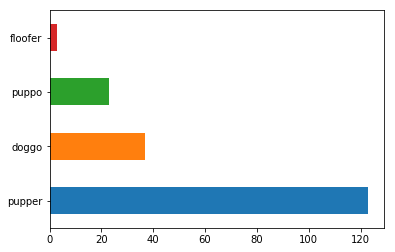

```python
dogs_data['dog_type'].value_counts().plot(kind='barh')
```

### Floofer

##### Deserved?!

```python
# get all floofers
floofer = dogs_data[dogs_data['dog_type'] == 'floofer']
# all photos' urls of floofers
urls = floofer['jpg_url'].tolist()
```

[figure not shown]

[figure not shown]

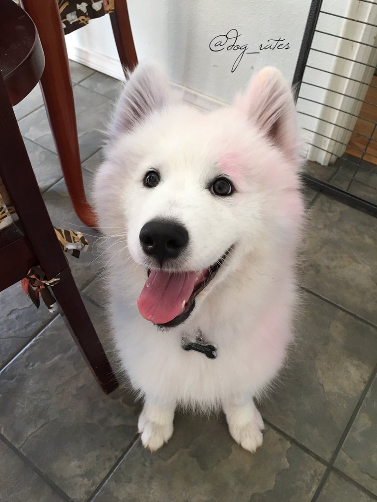

```python
images = []
for url in urls:
    images.append(IPython.display.Image(url, width = 250))

for ima in images:
    IPython.display.display(ima)
```

Last one seems cute, but DESERVED

## Favourited dog name.

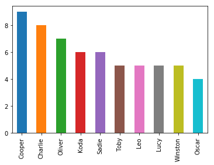

```python
dogs_data['name'].value_counts(sort=True, ascending=False)[0:10].plot(kind='bar')
```

### Cooper

Is that name related to a dog type?!

```python
dogs_data[dogs_data['name'] == 'Cooper']['dog_type'].unique()
```

```
array([nan, 'pupper', 'puppo'], dtype=object)
```

Puppo and Puuper? are those two types share a common something?

```python
puppo_pupper = dogs_data[dogs_data['name'] == 'Cooper']
puppo_pupper['dog_type']
```

```
69        NaN
223    pupper
255       NaN
282       NaN
408       NaN
432     puppo
602       NaN
653    pupper
865       NaN
Name: dog_type, dtype: object
```

[figure not shown]

```python
IPython.display.Image(puppo_pupper['jpg_url'][432])
```

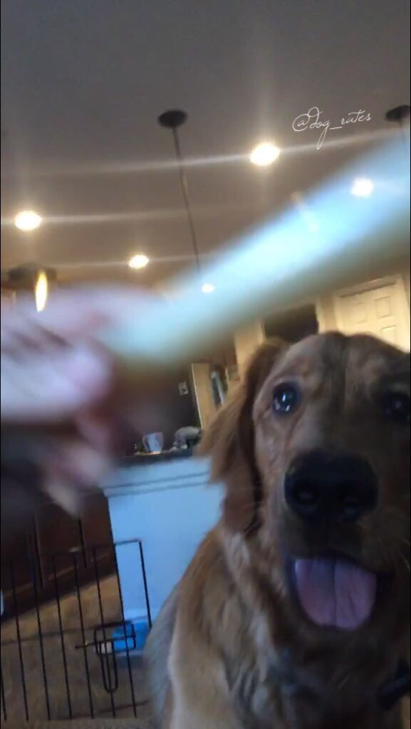

```python
IPython.display.Image(puppo_pupper['jpg_url'][653])
```

IDK!

## Most used source to tweet

```python
dogs_data.head(1)
```

|  | tweet_id | timestamp | source | name | dog_type | ratings | jpg_url | img_num | p1 | p1_conf | p2 | p2_conf | p3 | p3_conf | favorite_count | retweet_count |
| --- | --- | --- | --- | --- | --- | --- | --- | --- | --- | --- | --- | --- | --- | --- | --- | --- |
| 0 | 892177421306343426 | 2017-08-01 00:17:27 | Twitter for iPhone | Tilly | NaN | 1.3 | https://pbs.twimg.com/media/DGGmoV4XsAAUL6n.jpg | 1 | Chihuahua | 0.323581 | Pekinese | 0.090647 | papillon | 0.068957 | 33819 | 6514 |

```
array([<matplotlib.axes._subplots.AxesSubplot object at 0x0000017FD02E7828>],
      dtype=object)
```

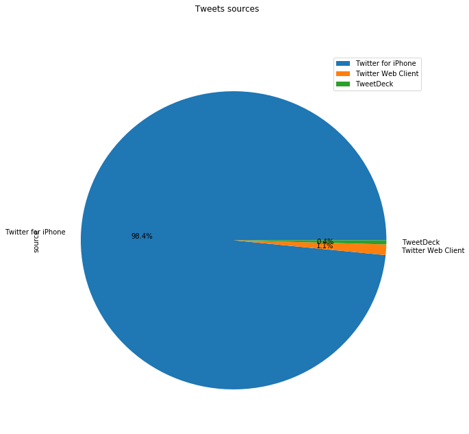

```python
dogs_data.source.value_counts().plot.pie( subplots=True,figsize=(10,10), legend=True, autopct='%.1f%%',title='Tweets sources')
```

## Most common rating

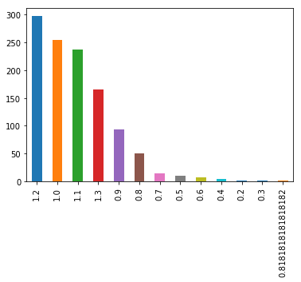

```python
dogs_data.ratings.value_counts().plot(kind='bar')
```

#### 1.2

[figure not shown]